# Has Data Science Shown Financial Markets are Not Efficient?

Karan Garg

## Introduction

In this paper, I aim to explore the role of data science literature in determining whether or not markets are efficient. Many papers claim to generate supernormal returns with their models (using just past prices), implying weak-form inefficiency, however the type of efficiency is rarely discussed. Fama-EMH efficiency may certainly be going down, but Lo-AMH or Samuelson-EMH efficiency may still be preserved. 2 ML algorithms, random forests and then LSTMs are used to assess whether this is the case.

If the models are able to predict prices well (such that a long-term strategy may be possibly used to generate above-market returns), then that may be evidence markets are not Fama-EMH efficient. However, they may still be Samuelson-EMH efficient if those predictions follow a martingale (best guess for next price is just the previous price), in which case this model is just getting lucky with their results.

```r
print("hello world")
```

```
## [1] "hello world"
```

## Dataset, Preparation and Feature Engineering

```r
#First we download the data from Quandl
#The data is imported as both a tibble and a timeseries object, as both will be useful for analysis

Quandl.api_key('rTCfeqfv2pbfQG-uk-af')
hsbc_tib <- Quandl('HKEX/00005', column_index = "1") %>%
  as_tsibble(index="Date")

names(hsbc_tib)[2] <- "Price"
dates <- seq(as.Date("2014-02-21"), as.Date("2021-05-05"), by = "day")
hsbc_ts <- as.ts(hsbc_tib, start = c(2014, as.numeric(format(dates[1], "%j"))), frequency=365)
```

```r
glimpse(hsbc_tib)
```

```
## Rows: 1,767
## Columns: 2
## $ Date  <date> 2014-02-21, 2014-02-24, 2014-02-25, 2014-02-26, 2014-02-27, 20…
## $ Price <dbl> 84.35, 83.85, 81.65, 81.15, 81.85, 82.25, 81.40, 81.50, 81.30, …
```

```r
glimpse(hsbc_ts)
```

```
##  Time-Series [1:2631] from 2014 to 2021: 84.3 NA NA 83.8 81.7 ...
```

```r
head(hsbc_tib)
```

```
## # A tsibble: 6 x 2 [1D]
##   Date       Price
##   <date>     <dbl>
## 1 2014-02-21  84.4
## 2 2014-02-24  83.8
## 3 2014-02-25  81.6
## 4 2014-02-26  81.2
## 5 2014-02-27  81.8
## 6 2014-02-28  82.2
```

```r
head(hsbc_ts)
```

```
## Time Series:
## Start = c(2014, 52)
## End = c(2014, 57)
## Frequency = 365
## [1] 84.35    NA    NA 83.85 81.65 81.15
```

```r
has_gaps(hsbc_tib)
```

```
## # A tibble: 1 x 1
##   .gaps
##   <lgl>
## 1 TRUE
```

```r
colSums(is.na(hsbc_tib[, "Price"]))
```

```
## Price
##     0
```

The data has no missing values, however it does contain gaps as the stock market is closed on weekends, bank holidays, etc and so the stock exchanges do not record a price for those days. In order to prevent this being a problem, the missing values are replaced with the last available price. While this may not reflect the change in price resulting from non-market orders placed over the weekend, it should solve the problem of the missing values without altering the key elements of the data.

```r
ImputeMissing <- function(ts){
  df <- data.frame(ts)
  for(i in 1:nrow(df)){
    if(is.na(df[i, 1])){
      df[i, 1] <- df[i-1, 1]
    }
  }
  dates_formatted <- data.frame(dates)
  df <- cbind(df, dates_formatted)
  names(df)[1] <- "Price"
  names(df)[2] <- "Date"
  tib_new <- as_tsibble(df)
#                  start = c(2014, 32),
#                  frequency=365)

  return(tib_new)
}
```

```r
hsbc_tib <- ImputeMissing(hsbc_ts)
```

```
## Using `Date` as index variable.
```

```r
hsbc_ts <- as.ts(hsbc_tib, start = c(2014, as.numeric(format(dates[1], "%j"))), frequency=365)
```

```r
head(hsbc_tib)
```

```
## # A tsibble: 6 x 2 [1D]
##   Price Date
##   <dbl> <date>
## 1  84.4 2014-02-21
## 2  84.4 2014-02-22
## 3  84.4 2014-02-23
## 4  83.8 2014-02-24
## 5  81.6 2014-02-25
## 6  81.2 2014-02-26
```

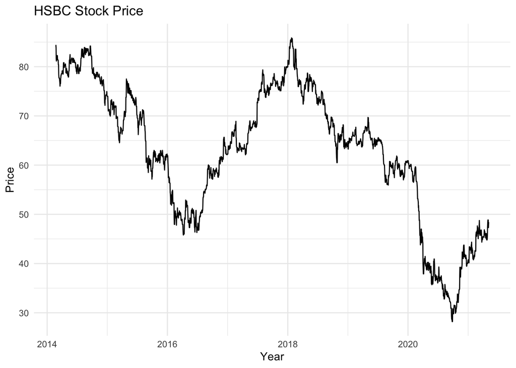

```r
hsbc_visual <- hsbc_tib %>%
  ggplot(aes(Date, Price)) +
  geom_line() +
  theme_minimal() +
  labs(title = "HSBC Stock Price", x = "Year", y = "Price")

print(hsbc_visual)
```

```r
#acf(hsbc_tib, lag.max = 10, na.action=na.pass)
```

```r
adf.test(hsbc_tib$Price)
```

```
## Augmented Dickey-Fuller Test
## alternative: stationary
##
## Type 1: no drift no trend
##       lag   ADF p.value
##  [1,]   0 -1.41   0.174
##  [2,]   1 -1.37   0.188
##  [3,]   2 -1.34   0.200
##  [4,]   3 -1.31   0.212
##  [5,]   4 -1.24   0.236
##  [6,]   5 -1.22   0.241
##  [7,]   6 -1.27   0.226
##  [8,]   7 -1.31   0.212
##  [9,]   8 -1.27   0.225
## Type 2: with drift no trend
```

[output cut: 23 more lines]

The ADF test revealed that the timeseries is non-stationary. In order to make the data easier for the model to process, we will difference the data and repeat the ADF test. Assuming the timeseries is I(1), a first-difference series should be stationary.

```r
hsbc_log_diff <- hsbc_ts %>%
  log() %>%
  diff(1)
```

```r
head(hsbc_log_diff)
```

```
## Time Series:
## Start = c(2014, 53)
## End = c(2014, 58)
## Frequency = 365
## [1]  0.000000000  0.000000000 -0.005945321 -0.026587669 -0.006142525
## [6]  0.008589010
```

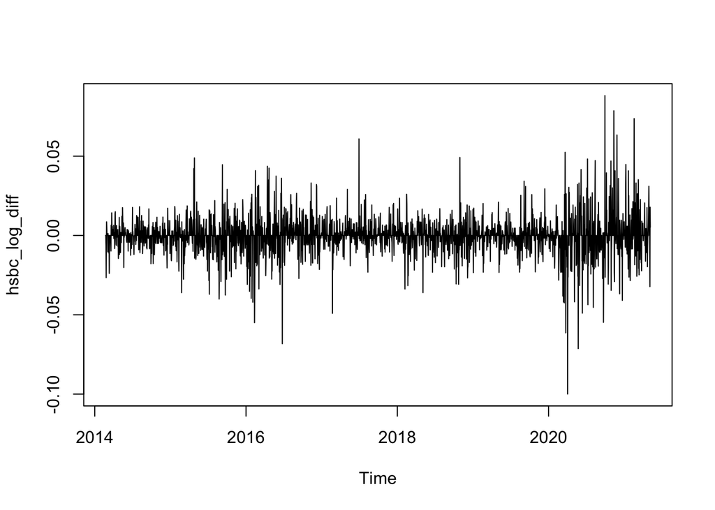

```r
plot(hsbc_log_diff)
```

```r
adf.test(hsbc_log_diff)
```

```
## Augmented Dickey-Fuller Test
## alternative: stationary
##
## Type 1: no drift no trend
##       lag   ADF p.value
##  [1,]   0 -48.8    0.01
##  [2,]   1 -34.2    0.01
##  [3,]   2 -28.5    0.01
##  [4,]   3 -25.4    0.01
##  [5,]   4 -23.1    0.01
##  [6,]   5 -21.6    0.01
##  [7,]   6 -20.0    0.01
##  [8,]   7 -18.1    0.01
##  [9,]   8 -17.1    0.01
## Type 2: with drift no trend
```

[output cut: 23 more lines]

We can see from the results, that this first-difference logged series is indeed stationary.

```r
hsbc_lagged <- embed(hsbc_log_diff, 22)
```

```r
split_num <- round(nrow(hsbc_lagged)*0.7)
hsbc_train <- hsbc_lagged[1: split_num, ]
hsbc_test <- hsbc_lagged[(split_num+1):nrow(hsbc_lagged), ]
X_train <- hsbc_train[, -1]
y_train <- hsbc_train[, 1]
X_test <- hsbc_test[, -1]
y_test <- hsbc_test[, 1]
```

## Model and Analysis

```r
linear <- lm(y_train ~ X_train)
summary(linear)
```

```
##
## Call:
## lm(formula = y_train ~ X_train)
##
## Residuals:
##       Min        1Q    Median        3Q       Max
## -0.065015 -0.002993  0.000074  0.003294  0.060855
##
## Coefficients:
##               Estimate Std. Error t value Pr(>|t|)
## (Intercept) -0.0001127  0.0002222  -0.507 0.612075
## X_train1     0.0215106  0.0235349   0.914 0.360846
## X_train2     0.0432355  0.0234968   1.840 0.065924 .
## X_train3     0.0271075  0.0234757   1.155 0.248364
## X_train4    -0.0305765  0.0234600  -1.303 0.192622
## X_train5     0.0236856  0.0234629   1.009 0.312874
## X_train6    -0.0268806  0.0234676  -1.145 0.252182
## X_train7    -0.0656587  0.0234761  -2.797 0.005215 **
## X_train8     0.0854780  0.0235250   3.634 0.000287 ***
## X_train9    -0.0452975  0.0236130  -1.918 0.055227 .
## X_train10   -0.0045582  0.0236299  -0.193 0.847059
## X_train11    0.0051909  0.0236300   0.220 0.826149
## X_train12    0.0136432  0.0236297   0.577 0.563759
## X_train13   -0.0037877  0.0236084  -0.160 0.872552
## X_train14    0.0121115  0.0235184   0.515 0.606630
## X_train15   -0.0259538  0.0234703  -1.106 0.268954
## X_train16   -0.0142846  0.0234623  -0.609 0.542713
## X_train17    0.0121914  0.0234569   0.520 0.603311
## X_train18   -0.0463447  0.0233979  -1.981 0.047774 *
## X_train19   -0.0152738  0.0234130  -0.652 0.514250
## X_train20   -0.0615960  0.0233929  -2.633 0.008533 **
## X_train21    0.0278615  0.0234345   1.189 0.234632
## ---
## Signif. codes:  0 '***' 0.001 '**' 0.01 '*' 0.05 '.' 0.1 ' ' 1
##
## Residual standard error: 0.009475 on 1804 degrees of freedom
## Multiple R-squared:  0.02784,    Adjusted R-squared:  0.01652
## F-statistic:  2.46 on 21 and 1804 DF,  p-value: 0.0002479
```